# Practical Machine Learning Project

Rakesh Prusty

November 22, 2016

# Background

One thing that people regularly do is quantify how much of a particular activity they do, but they rarely quantify how well they do it. In this project, data used from accelerometers on the belt, forearm, arm, and dumbell of 6 participants. They were asked to perform barbell lifts correctly and incorrectly in 5 different ways. Goal of the project is to predict the manner in which they did the exercise. This is the “classe” variable which we need to predict.

# Processing

## Load Libraries

We will load all the required packages.

```r
library(caret); library(rattle); library(rpart); library(rpart.plot);
library(randomForest)
```

## Import data

The data was downloaded from the links and saved in the working folder and then data was read to training and testing datasets respectively.

```r
training <- read.csv("pml-training.csv",na.strings = c("NA", ""))
testing <- read.csv("pml-testing.csv",na.strings = c("NA", ""))
dim(training)
```

```
## [1] 19622   160
```

```r
dim(testing)
```

```
## [1]  20 160
```

The training dataset has 19622 records and 160 variables. Testing dataset has 20 records with same variables as training. We will predict the “classe” variable in training set.

## Cleansing Data

Now, we will try to remove the columns with all missing (“NA”) values.

```r
sh_training <- training[,colSums(is.na(training))==0]
sh_testing <- testing[,colSums(is.na(testing))==0]
```

The first seven variables of both training and testing data are not useful for prediction. Let’s remove the variables from processing.

```r
trainData <- sh_training[,-c(1:7)]
testData <- sh_testing[,-c(1:7)]
```

The final data has 53 variables.

## Data Splitting

The training data is now subdivided into a sub training and validation set.We will use 70% data for the sub training and rest for the sub testing set.

```r
set.seed(4321)
inTrain <- createDataPartition(trainData$classe,p=0.7,list = FALSE)
subtrain <- trainData[inTrain,]
subtest <- trainData[-inTrain,]
```

## Model Building and Prediction

We will use classification trees and random forests to predict.

### Classification Trees

We will use 5 fold cross validation while rpart model fitting.

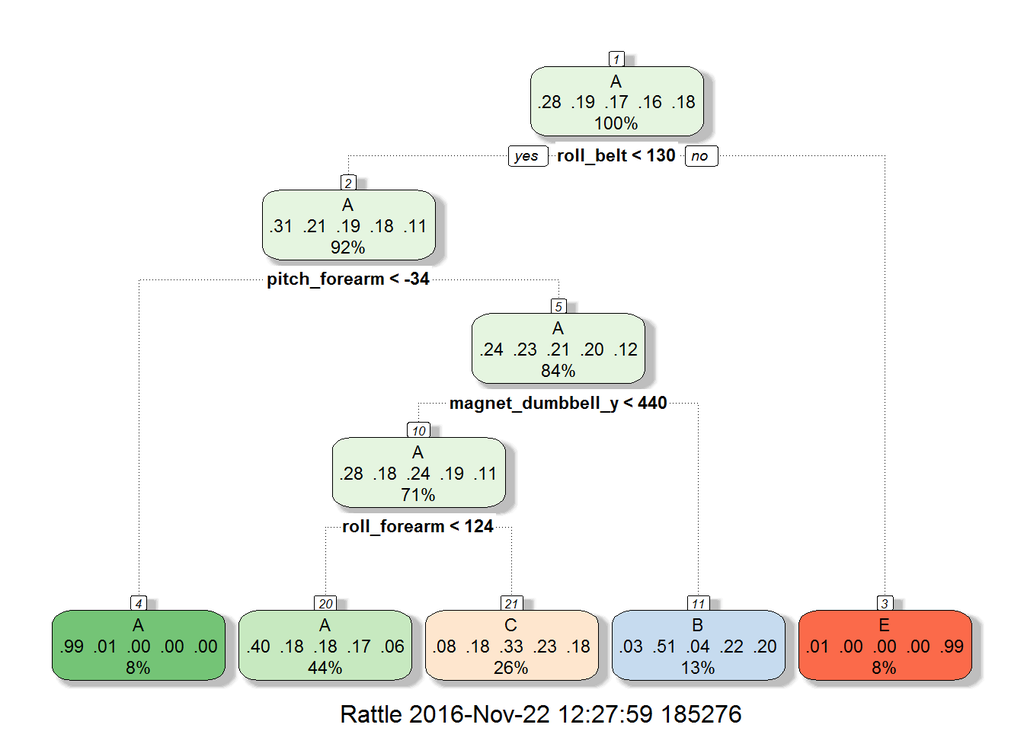

```r
rpart_mod <- train(classe~.,data=subtrain,method="rpart",trControl=trainControl(method = "cv",number = 5))
#Plot the classification tree
fancyRpartPlot(rpart_mod$finalModel)
```

```r
#Predict outcome using subtest dataset
rpart_pred <- predict(rpart_mod,subtest)
rpart_accuracy <- confusionMatrix(subtest$classe,rpart_pred)$overall[1]
rpart_outofsample_error <- 1-rpart_accuracy
```

The accuracy of the prediction is 0.495497 and the out of sample error is 0.504503. It’s clear that classification does not predict the “classe” variable well.

### Random Forests

Now we will try Random Forests model for prediction using 5 fold cross validation.

```r
rf_mod <- train(classe~.,data=subtrain,method="rf",trControl=trainControl(method = "cv",number = 5))
#Predict outcome using subtest dataset
rf_pred <- predict(rf_mod,subtest)
rf_accuracy <- confusionMatrix(subtest$classe,rf_pred)$overall[1]
rf_outofsample_error <- 1-rf_accuracy
```

The accuracy of the prediction is 0.9923534 and the out of sample error is 0.0076466. Because of this high accuracy rate we will use Random Forest model on the final test data set.

# Prediction on Test Set

```r
#Predict outcome using test dataset
rf_pred <- predict(rf_mod,testData)
rf_pred
```

```
##  [1] B A B A A E D B A A B C B A E E A B B B
## Levels: A B C D E
```